# Decision Trees- Classification

Author

Sheeba Moghal

# Introduction

A supervised learning classifier is a machine learning model that has been trained on labelled data and has learned to associate input features with corresponding output labels. It extrapolates from the training set to predict labels for fresh, previously unknown data. During training, the classifier learns patterns and optimises parameters to minimise prediction errors. It is used for classification and regression tasks, such as classifying data into predetermined groups or predicting continuous values. Decision trees, support vector machines, and neural networks are examples of common classifiers. By exploiting learnt patterns from labelled samples, they enable automated decision-making and insight extraction in a variety of fields such as spam detection, picture recognition, and predictive analytics. For this project, decision tree and random forest classifiers are explored.

For my economic data essentially, since it is not categorical in nature, trying to find a categorical realm within the dataset was difficult, hence it was soley categorised on basis of performance keeping in mind the GDP growth rate. Hence, the Y variables are categorical in nature and the X taken is numerical in nature. An attempt here is made to understand the predictive capabilities of the Decision Tree and Random Forest Classifiers.

# Decision Tree Classifier

Decision tree classification is a machine learning approach that is well-known for its ability to categorise data. It adopts a tree-like hierarchical structure in which each node indicates a choice based on specified features, resulting in a cyclical creation process. Nodes represent features, whereas leaves represent the ultimate decision or output label. The algorithm finds the best feature to partition the data at each node, with the goal of increasing homogeneity. The algorithm’s decisions are guided by decision-making factors such as Gini impurity or entropy. Predictions are made by traversing the tree from root to leaf, with the related label of the leaf forming the final prediction. Decision trees are interpretable, making them appropriate for non-experts. They are adaptable due to their lack of assumptions about data distribution and flexibility to simulate complex relationships. Medical diagnosis, client segmentation, fraud detection, and image recognition are just a few of the applications. Overfitting and susceptibility to noisy data are challenges that can be reduced with strategies like pruning. It is different from a Decision Tree Regressor as instead of categorical variables, it predicts the continuous variables.

```python
# importing relevant libraries

import numpy as np
import pandas as pd
import matplotlib.pyplot as plt
import seaborn as sns
from sklearn.tree import DecisionTreeClassifier
from sklearn import metrics
from sklearn.model_selection import train_test_split, GridSearchCV
from sklearn.model_selection import RandomizedSearchCV
from sklearn.metrics import accuracy_score, classification_report
from sklearn.tree import plot_tree
from sklearn.metrics import confusion_matrix, ConfusionMatrixDisplay
from sklearn.ensemble import RandomForestClassifier
```

```python
stackeddf= pd.read_csv("../data/stackeddf.csv")

stackeddf.head(5)
```

|  | year | adj_NNI_g | adj_savings_fix_cap_GNI | adj_savings_edu_GNI | adj_NNS_GNI | ex_imp_growth | ex_debt_shocks | fdi_net_outflows | gdp_growth | short_term_debt_tot_reserves | lending_interest_rate | life_exp_birth | expense_gdp | military expenditure | labels |
| --- | --- | --- | --- | --- | --- | --- | --- | --- | --- | --- | --- | --- | --- | --- | --- |
| 0 | -1.647859 | 1.230366 | 0.270892 | -0.277537 | -0.052004 | 0.419580 | -1.270470 | -0.842531 | 1.595002 | -0.032164 | -0.845342 | -0.112698 | -0.121526 | -0.167829 | High Growth |
| 1 | -1.572340 | -1.216110 | 0.313510 | -0.277537 | 0.103127 | -0.481153 | -1.204634 | -0.842808 | 1.304262 | 0.403253 | -0.845342 | -0.110878 | -0.141348 | -0.151690 | High Growth |
| 2 | -1.496821 | -0.510146 | 0.367195 | -0.277537 | 0.049534 | 0.536099 | -0.969857 | -0.842942 | 0.295912 | 0.851964 | -0.845342 | -0.109081 | -0.105898 | -0.102821 | Moderate Growth |
| 3 | -1.421301 | 1.160350 | 0.316780 | -0.277537 | 0.046547 | -0.495731 | -0.889487 | -0.842495 | 1.815392 | 1.403674 | -0.845342 | -0.107310 | -0.098738 | -0.109603 | Very High Growth |
| 4 | -1.345782 | -0.472199 | 0.362786 | -0.277537 | 0.058430 | 0.726138 | -0.708319 | -0.842596 | 0.433390 | 1.517825 | -0.845342 | -0.105584 | -0.034063 | -0.080748 | Moderate Growth |

```python
X= stackeddf.drop(['year'], axis=1)
X= X.drop(['labels'], axis=1)
Y= stackeddf['labels']

print(X.head(3))
print(Y.head(3))
```

```
   adj_NNI_g  adj_savings_fix_cap_GNI  adj_savings_edu_GNI  adj_NNS_GNI  \
0   1.230366                 0.270892            -0.277537    -0.052004
1  -1.216110                 0.313510            -0.277537     0.103127
2  -0.510146                 0.367195            -0.277537     0.049534

   ex_imp_growth  ex_debt_shocks  fdi_net_outflows  gdp_growth  \
0       0.419580       -1.270470         -0.842531    1.595002
1      -0.481153       -1.204634         -0.842808    1.304262
2       0.536099       -0.969857         -0.842942    0.295912

   short_term_debt_tot_reserves  lending_interest_rate  life_exp_birth  \
0                     -0.032164              -0.845342       -0.112698
1                      0.403253              -0.845342       -0.110878
2                      0.851964              -0.845342       -0.109081

   expense_gdp  military expenditure
0    -0.121526             -0.167829
1    -0.141348             -0.151690
2    -0.105898             -0.102821
0        High Growth
1        High Growth
2    Moderate Growth
Name: labels, dtype: object
```

Since year is not considered in the dataset as the data consists of stacking the dataframe, we drop that and define the dependant and the independant variable. The dependant variable here is the ‘label’ and the independant variable is all the numerical columns that have been standarised using the standard scalar

```python
# the class distribution of the labels

distribution = stackeddf['labels'].value_counts()

# Print the distribution
print("Class Distribution:")
print(distribution)
```

```
Class Distribution:
labels
Low Growth          88
Moderate Growth     72
Very High Growth    18
High Growth         17
Name: count, dtype: int64
```

In terms of the distribution, we see that Low Growth is the most and High Growth is the least, that is also visually shown below.

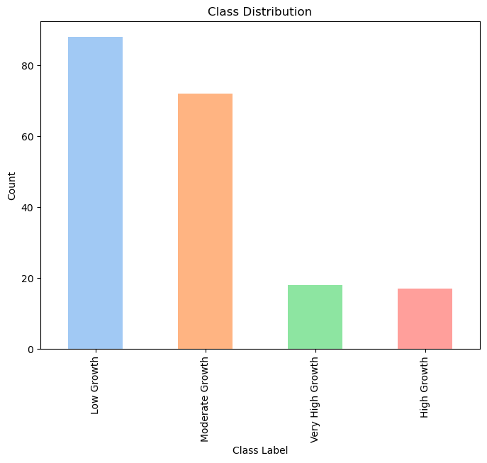

```python
colors = sns.color_palette('pastel', len(distribution))
plt.figure(figsize=(8, 6))
distribution.plot(kind='bar', color=colors)
plt.title('Class Distribution')
plt.xlabel('Class Label')
plt.ylabel('Count')
plt.show()
```

## Baseline Decision Tree Classifier

Having a classifier with default parameters is important to analyse the predictive capabilities of the model. It helps us understand how the original tree would look like.

```python
# splitting into training, testing and validation
X_train, X_temp, y_train, y_temp = train_test_split(X, Y, test_size=0.4, random_state=42)
X_val, X_test, y_val, y_test = train_test_split(X_temp, y_temp, test_size=0.5, random_state=42)

# baseline decisoon tree classifier
baseline_decision_tree = DecisionTreeClassifier(random_state=42)

# Train the base model on the training set
baseline_decision_tree.fit(X_train, y_train)

# predictions on training test
baseline_train_pred = baseline_decision_tree.predict(X_train)

# predictions on test set
baseline_test_pred = baseline_decision_tree.predict(X_test)

# predictions on validation set
baseline_validation_pred = baseline_decision_tree.predict(X_val)
```

```python
# accuracy for training
baseline_training_acc = accuracy_score(y_train, baseline_train_pred)
print("Base Decision Tree Accuracy on Training Set:", baseline_training_acc)

# accuracy for testing
baseline_testing_acc = accuracy_score(y_test, baseline_test_pred)
print("Base Decision Tree Accuracy on Testing Set:", baseline_testing_acc)

# accuracy for validation
baseline_validation_acc = accuracy_score(y_val, baseline_validation_pred)
print("Base Decision Tree Accuracy on Validation Set:", baseline_validation_acc)
```

```
Base Decision Tree Accuracy on Training Set: 0.6410256410256411
Base Decision Tree Accuracy on Testing Set: 0.2564102564102564
Base Decision Tree Accuracy on Validation Set: 0.3333333333333333
```

```python
# classification report on training
print("Classification Report for Basal Decision Tree on Training Set:")
print(classification_report(y_train, baseline_train_pred))

# classification report on testing
print("Classification Report for Basal Decision Tree on Testing Set:")
print(classification_report(y_test, baseline_test_pred))

# classification report on validation
print("Classification Report for Basal Decision Tree on Validation Set:")
print(classification_report(y_val, baseline_validation_pred))
```

```
Classification Report for Basal Decision Tree on Training Set:
                  precision    recall  f1-score   support

     High Growth       0.36      0.56      0.43         9
      Low Growth       0.61      0.84      0.70        51
 Moderate Growth       0.83      0.51      0.63        49
Very High Growth       1.00      0.25      0.40         8

        accuracy                           0.64       117
       macro avg       0.70      0.54      0.54       117
    weighted avg       0.71      0.64      0.63       117

Classification Report for Basal Decision Tree on Testing Set:
                  precision    recall  f1-score   support

     High Growth       0.00      0.00      0.00         4
      Low Growth       0.33      0.32      0.32        19
 Moderate Growth       0.33      0.33      0.33        12
Very High Growth       0.00      0.00      0.00         4

        accuracy                           0.26        39
       macro avg       0.17      0.16      0.16        39
    weighted avg       0.26      0.26      0.26        39

Classification Report for Basal Decision Tree on Validation Set:
                  precision    recall  f1-score   support

     High Growth       0.00      0.00      0.00         4
      Low Growth       0.45      0.56      0.50        18
 Moderate Growth       0.21      0.27      0.24        11
Very High Growth       0.00      0.00      0.00         6

        accuracy                           0.33        39
       macro avg       0.17      0.21      0.18        39
    weighted avg       0.27      0.33      0.30        39
```

In the training, testing, and validation sets, the accuracy of the baseline Decision Tree classifier varies. With an accuracy of 64.1% on the training set, the data is reasonably fitted. On the testing and validation sets, however, this performance declines, with accuracies falling to 25.6% and 33.3%, respectively. The low recall scores in the classification reports highlight the model’s difficulty correctly identifying instances within each class. The model does a good job of identifying Low Growth instances in the training set, but it has trouble with the High Growth and Very High Growth classes. The model’s inability to successfully generalise to new data is evident in the testing and validation sets, where the performance gap widens. The dataset is unbalanced when taking the class distribution into account, with a significant concentration of Low Growth cases. This imbalance probably makes it harder for the model to predict minority classes with any degree of accuracy.

In terms of the classification report

The model performs reasonably well in the training set in terms of precision, recall, and F1-scores for the majority of classes, but it has trouble with the High Growth category. On the testing and validation sets, however, the model’s performance drastically declines, indicating problems with generalisation. The model’s poor recall and precision in all classes point to its limited capacity to correctly classify instances in unknown data. The model’s shortcomings suggest that overfitting may be a problem.

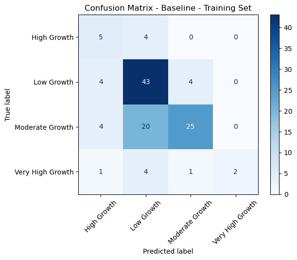

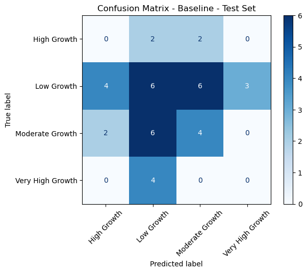

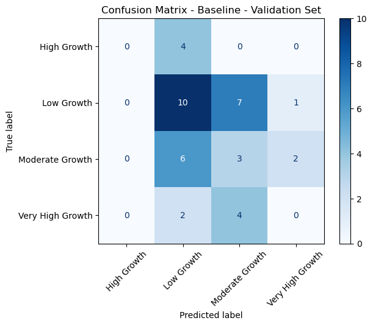

```python
# defined function for confusion matrix
def plot_confusion_matrix(y_true, y_pred, classes, title):
    cm = confusion_matrix(y_true, y_pred, labels=classes)
    disp = ConfusionMatrixDisplay(confusion_matrix=cm, display_labels=classes)
    disp.plot(cmap="Blues")
    plt.title(title)
    plt.xticks(rotation=45)  # Rotate x-axis labels for better visibility
    plt.show()

plot_confusion_matrix(y_train, baseline_train_pred, classes=np.unique(Y), title="Confusion Matrix - Baseline - Training Set")
plot_confusion_matrix(y_test, baseline_test_pred, classes=np.unique(Y), title="Confusion Matrix - Baseline - Test Set")
plot_confusion_matrix(y_val, baseline_validation_pred, classes=np.unique(Y), title="Confusion Matrix - Baseline - Validation Set")
```

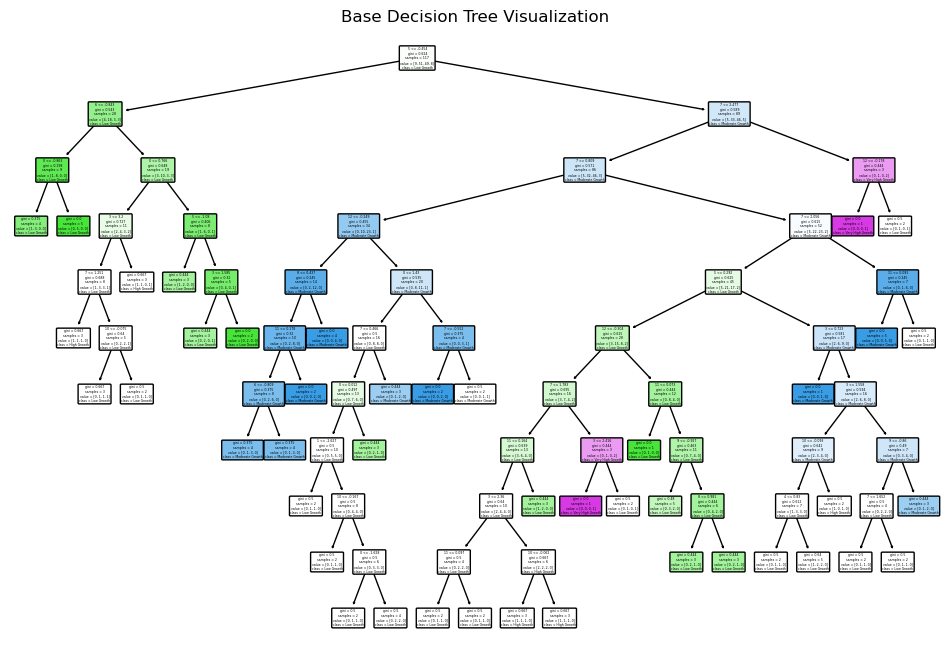

```python
plt.figure(figsize=(12, 8))
plot_tree(baseline_decision_tree, filled=True, feature_names=[str(i) for i in range(X.shape[1])], class_names=np.unique(Y).astype(str), rounded=True)
plt.title("Base Decision Tree Visualization")
plt.show()
```

This is the visualisation of the tree, that suggests more hyperparameter tuning.

# Decision Tree Classifier : GridSearchCV

```python
param_grid = {
    'criterion': ['gini', 'entropy'],
    'splitter': ['best', 'random'],
    'max_depth': [None, 10, 20, 30, 40, 50],
    'min_samples_split': [2, 5, 10],
    'min_samples_leaf': [1, 2, 4]
}
```

```python
grid_search = GridSearchCV(baseline_decision_tree, param_grid, cv=5, scoring='accuracy', verbose=1, n_jobs=-1)
grid_search.fit(X_train, y_train)
```

```
Fitting 5 folds for each of 216 candidates, totalling 1080 fits
```

```
GridSearchCV(cv=5, estimator=DecisionTreeClassifier(random_state=42), n_jobs=-1,
             param_grid={'criterion': ['gini', 'entropy'],
                         'max_depth': [None, 10, 20, 30, 40, 50],
                         'min_samples_leaf': [1, 2, 4],
                         'min_samples_split': [2, 5, 10],
                         'splitter': ['best', 'random']},
             scoring='accuracy', verbose=1)
```

```python
# Get the best model
gridsearch_dt = grid_search.best_estimator_
gridsearch_dt
```

```
DecisionTreeClassifier(criterion='entropy', max_depth=10, min_samples_split=10,
                       random_state=42, splitter='random')
```

```python
optimal_dt_model = DecisionTreeClassifier(
    criterion=gridsearch_dt.criterion,
    splitter=gridsearch_dt.splitter,
    max_depth=gridsearch_dt.max_depth,
    min_samples_split=gridsearch_dt.min_samples_split,
    min_samples_leaf=gridsearch_dt.min_samples_leaf,
    random_state=42
)
optimal_dt_model.fit(X_train, y_train)
```

```
DecisionTreeClassifier(criterion='entropy', max_depth=10, min_samples_split=10,
                       random_state=42, splitter='random')
```

```python
from sklearn.metrics import accuracy_score, classification_report

# predictions on training test
optimal_train_pred_gcv = optimal_dt_model.predict(X_train)

# predictions on test set
optimal_test_pred_gcv = optimal_dt_model.predict(X_test)

# predictions on validation set
optimal_validation_pred_gcv = optimal_dt_model.predict(X_val)
```

```python
# accuracy for training
optimal_train_acc_gcv = accuracy_score(y_train, optimal_train_pred_gcv)
print("GridSearchCV Decision Tree Accuracy on Training Set:", optimal_train_acc_gcv*100)

# accuracy for testing
optimal_test_acc_gcv = accuracy_score(y_test, optimal_test_pred_gcv)
print("GridSearchCV Decision Tree Accuracy on Test Set:", optimal_test_acc_gcv*100)

# accuracy for validation
optimal_validation_acc_gcv = accuracy_score(y_val, optimal_validation_pred_gcv)
print("GridSearchCV Decision Tree Accuracy on Validation Set:", optimal_validation_acc_gcv*100)
```

```
GridSearchCV Decision Tree Accuracy on Training Set: 63.24786324786324
GridSearchCV Decision Tree Accuracy on Test Set: 38.46153846153847
GridSearchCV Decision Tree Accuracy on Validation Set: 35.8974358974359
```

In terms of the classification report,the model attains an accuracy of 63.25% on the training set, exhibiting noteworthy precision, recall, and F1-score values in various classes. But the accuracy of the test and validation sets shows a decrease, at 38.46% and 35.90%, respectively. The model exhibits good performance in detecting “Low Growth” cases, with precision and recall values ranging from 0.45 to 0.53. Still, its precision, recall, and F1-score values are lower for these classes due to its limited ability to identify “High Growth” and “Very High Growth” instances.

```python
# classification report for training
print("Classification Report for GridSearchCV Decision Tree on Training Set:")
print(classification_report(y_train, optimal_train_pred_gcv))

# classification report for testing
print("Classification Report for GridSearchCV Decision Tree on Test Set:")
print(classification_report(y_test, optimal_test_pred_gcv))

# classification report for validation
print("Classification Report for GridSearchCV Decision Tree on Validation Set:")
print(classification_report(y_val, optimal_validation_pred_gcv))
```

```
Classification Report for GridSearchCV Decision Tree on Training Set:
                  precision    recall  f1-score   support

     High Growth       0.00      0.00      0.00         9
      Low Growth       0.59      0.73      0.65        51
 Moderate Growth       0.69      0.71      0.70        49
Very High Growth       0.67      0.25      0.36         8

        accuracy                           0.63       117
       macro avg       0.49      0.42      0.43       117
    weighted avg       0.59      0.63      0.60       117

Classification Report for GridSearchCV Decision Tree on Test Set:
                  precision    recall  f1-score   support

     High Growth       0.00      0.00      0.00         4
      Low Growth       0.45      0.53      0.49        19
 Moderate Growth       0.33      0.42      0.37        12
Very High Growth       0.00      0.00      0.00         4

        accuracy                           0.38        39
       macro avg       0.20      0.24      0.21        39
    weighted avg       0.32      0.38      0.35        39

Classification Report for GridSearchCV Decision Tree on Validation Set:
                  precision    recall  f1-score   support

     High Growth       0.00      0.00      0.00         4
      Low Growth       0.53      0.56      0.54        18
 Moderate Growth       0.21      0.36      0.27        11
Very High Growth       0.00      0.00      0.00         6

        accuracy                           0.36        39
       macro avg       0.18      0.23      0.20        39
    weighted avg       0.30      0.36      0.32        39
```

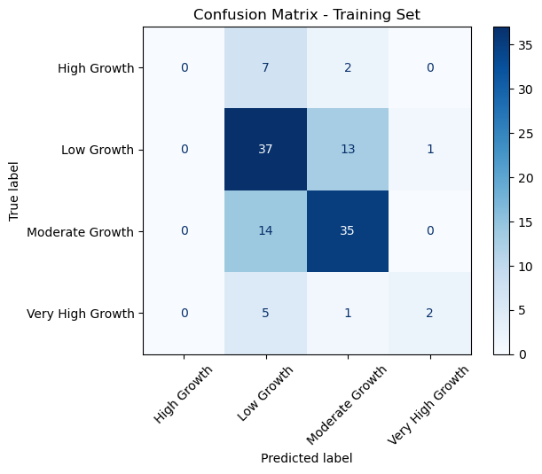

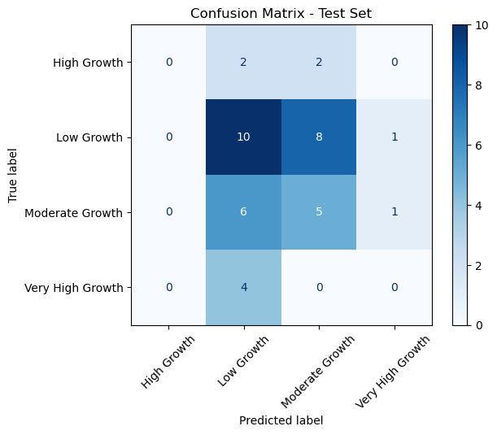

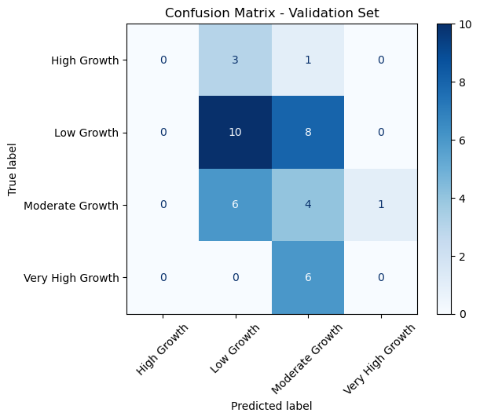

```python
# confusion matrix for GridsearchCV
plot_confusion_matrix(y_train, optimal_train_pred_gcv, classes=np.unique(Y), title="Confusion Matrix - Training Set")
plot_confusion_matrix(y_test, optimal_test_pred_gcv, classes=np.unique(Y), title="Confusion Matrix - Test Set")
plot_confusion_matrix(y_val, optimal_validation_pred_gcv, classes=np.unique(Y), title="Confusion Matrix - Validation Set")
```

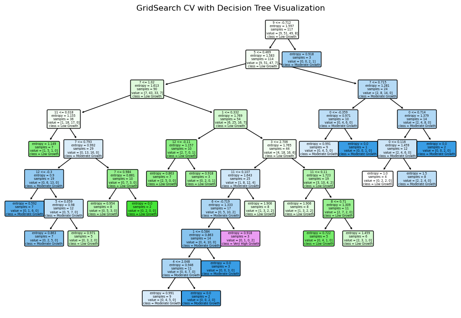

```python
plt.figure(figsize=(12, 8))
plot_tree(optimal_dt_model, filled=True, feature_names=[str(i) for i in range(X.shape[1])], class_names=np.unique(Y).astype(str), rounded=True)
plt.title("GridSearch CV with Decision Tree Visualization")
plt.show()
```

You see that the tree has been pruned. We can also see the information more clearly. For exploring more hyper-tuning methods, we used RandomisedSearchCV

# Decision Tree Classifier : RandomisedSearchCV

```python
param_dist = {
    'criterion': ['gini', 'entropy'],
    'splitter': ['best', 'random'],
    'max_depth': [None, 10, 20, 30, 40, 50],
    'min_samples_split': [2, 5, 10],
    'min_samples_leaf': [1, 2, 4]
}
```

```python
randomized_search = RandomizedSearchCV(baseline_decision_tree, param_distributions=param_dist, n_iter=50, cv=5, scoring='accuracy', verbose=1, n_jobs=-1, random_state=42)
randomized_search.fit(X_train, y_train)
```

```
Fitting 5 folds for each of 50 candidates, totalling 250 fits
```

```
RandomizedSearchCV(cv=5, estimator=DecisionTreeClassifier(random_state=42),
                   n_iter=50, n_jobs=-1,
                   param_distributions={'criterion': ['gini', 'entropy'],
                                        'max_depth': [None, 10, 20, 30, 40, 50],
                                        'min_samples_leaf': [1, 2, 4],
                                        'min_samples_split': [2, 5, 10],
                                        'splitter': ['best', 'random']},
                   random_state=42, scoring='accuracy', verbose=1)
```

```python
randomised_cv_best = randomized_search.best_estimator_
randomised_cv_best
```

```
DecisionTreeClassifier(criterion='entropy', max_depth=20, min_samples_leaf=4,
                       min_samples_split=10, random_state=42,
                       splitter='random')
```

```python
randomised_dt = DecisionTreeClassifier(
    criterion='entropy',
    max_depth=20, min_samples_leaf=4, min_samples_split=10, random_state=42, splitter='random')

randomised_dt.fit(X_train, y_train)
```

```
DecisionTreeClassifier(criterion='entropy', max_depth=20, min_samples_leaf=4,
                       min_samples_split=10, random_state=42,
                       splitter='random')
```

```python
# Make predictions on the training set
optimal_train_pred_rcv = randomised_dt.predict(X_train)

# Make predictions on the test set
optimal_test_pred_rcv = randomised_dt.predict(X_test)

# Make predictions on the validation set
optimal_val_pred_rcv = randomised_dt.predict(X_val)
```

```python
# accuracy for training
optimal_train_acc_rcv = accuracy_score(y_train, optimal_train_pred_rcv)
print("RandomisedSearchCV Decision Tree Accuracy on Training Set:" , optimal_train_acc_rcv)

# accuracy for testing
optimal_test_acc_rcv = accuracy_score(y_test, optimal_test_pred_rcv)
print("RandomisedSearchCV Decision Tree Accuracy on Test Set:", optimal_test_acc_rcv)

# accuracy for validation
optimal_validation_acc_rcv = accuracy_score(y_val, optimal_val_pred_rcv)
print("RandomisedSearchCV Decision Tree Accuracy on Validation Set:",optimal_validation_acc_rcv)
```

```
RandomisedSearchCV Decision Tree Accuracy on Training Set: 0.6153846153846154
RandomisedSearchCV Decision Tree Accuracy on Test Set: 0.358974358974359
RandomisedSearchCV Decision Tree Accuracy on Validation Set: 0.38461538461538464
```

```python
#  classification report for the model on the training set
print("Classification Report for RandomisedSearchCV Decision Tree on Training Set:")
print(classification_report(y_train, optimal_train_pred_rcv))

# classification report for the model on the test set
print("Classification Report for RandomisedSearchCV Decision Tree on Test Set:")
print(classification_report(y_test, optimal_test_pred_rcv))

#  classification report for the model on the validation set
print("Classification Report for RandomisedSearchCV Decision Tree on Validation Set:")
print(classification_report(y_val, optimal_val_pred_rcv))
```

```
Classification Report for RandomisedSearchCV Decision Tree on Training Set:
                  precision    recall  f1-score   support

     High Growth       0.00      0.00      0.00         9
      Low Growth       0.57      0.76      0.66        51
 Moderate Growth       0.69      0.63      0.66        49
Very High Growth       0.50      0.25      0.33         8

        accuracy                           0.62       117
       macro avg       0.44      0.41      0.41       117
    weighted avg       0.57      0.62      0.58       117

Classification Report for RandomisedSearchCV Decision Tree on Test Set:
                  precision    recall  f1-score   support

     High Growth       0.00      0.00      0.00         4
      Low Growth       0.44      0.42      0.43        19
 Moderate Growth       0.29      0.50      0.36        12
Very High Growth       0.00      0.00      0.00         4

        accuracy                           0.36        39
       macro avg       0.18      0.23      0.20        39
    weighted avg       0.30      0.36      0.32        39

Classification Report for RandomisedSearchCV Decision Tree on Validation Set:
                  precision    recall  f1-score   support

     High Growth       0.00      0.00      0.00         4
      Low Growth       0.57      0.44      0.50        18
 Moderate Growth       0.32      0.64      0.42        11
Very High Growth       0.00      0.00      0.00         6

        accuracy                           0.38        39
       macro avg       0.22      0.27      0.23        39
    weighted avg       0.35      0.38      0.35        39
```

The accuracy of the RandomisedSearchCV Decision Tree model varies depending on the dataset. The model’s accuracy of 61.54% on the training set shows that it can accurately classify instances in the dataset that it was trained on. The model performs slightly worse when used with unknown data, with test set accuracies of 35.90% and validation set accuracies of 38.46%.

The variations of the performance is shown by the RandomisedSearchCV Decision Tree model in different growth categories. It obtains 62% accuracy on the training set, showing remarkable precision for Moderate Growth (69%) but struggling with High Growth (0%). The accuracy of the tests varies, peaking at 44% for Low Growth. Recall is highest for Moderate Growth (50%). With a 38% accuracy, the validation set exhibits a balanced precision of 57% for Low Growth and a noteworthy recall of 64% for Moderate Growth. The model’s performance points to the need for improved methods, especially in terms of precisely forecasting High Growth occurrences.

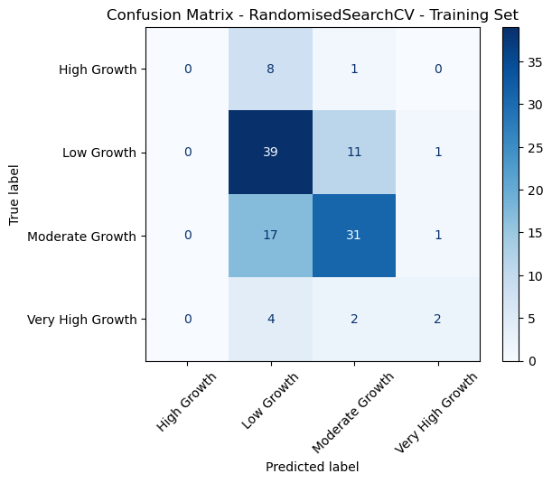

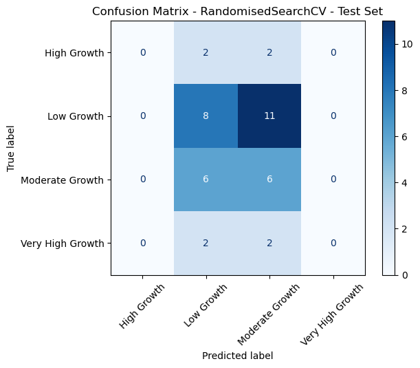

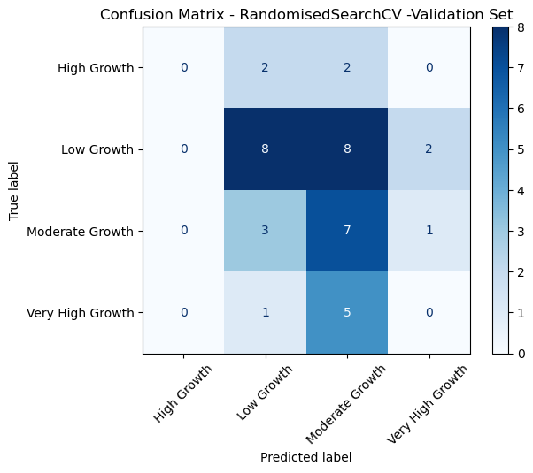

```python
plot_confusion_matrix(y_train, optimal_train_pred_rcv, classes=np.unique(Y), title="Confusion Matrix - RandomisedSearchCV - Training Set")
plot_confusion_matrix(y_test, optimal_test_pred_rcv, classes=np.unique(Y), title="Confusion Matrix - RandomisedSearchCV - Test Set")
plot_confusion_matrix(y_val, optimal_val_pred_rcv, classes=np.unique(Y), title="Confusion Matrix - RandomisedSearchCV -Validation Set")
```

[figure not shown]

```python
plt.figure(figsize=(12, 8))
plot_tree(randomised_dt, filled=True, feature_names=[str(i) for i in range(X.shape[1])], class_names=np.unique(Y).astype(str), rounded=True)
plt.title("GridSearch CV with Decision Tree Visualization")
plt.show()
```

You see here that the tree has been more pruned.

# Random Forest

An ensemble learning algorithm called a Random Forest Classifier integrates the predictions of several decision trees to enhance the overall performance of the model. By using random subsets of the training data and choosing a random subset of features at each split, it creates a large number of decision trees during training. By doing this, the trees become more diverse, which lowers the possibility of overfitting and improves the model’s ability to generalise effectively to new data. For classification tasks, a majority voting scheme is frequently used to aggregate the individual tree predictions and determine the final prediction. Compared to a single Decision Tree, Random Forests have a number of advantages. They offer better accuracy, are more resilient to noise and outliers, and are less prone to overfitting as a result of the ensemble’s averaging effect. They can also handle a high volume of input features and identify intricate relationships in the data. Just like above, we will work in the same basis.

## Random Forest Classifer - Baseline Model

```python
baseline_rf_model = RandomForestClassifier(random_state=42)
baseline_rf_model.fit(X_train, y_train)
```

```
RandomForestClassifier(random_state=42)
```

```python
# make predictions on the training, test, and validation data
train_predictions = baseline_rf_model.predict(X_train)
test_predictions = baseline_rf_model.predict(X_test)
val_predictions = baseline_rf_model.predict(X_val)
```

```python
#  accuracy for the training set
accuracy_train = accuracy_score(y_train, train_predictions)

#  accuracy for the test set
accuracy_test = accuracy_score(y_test, test_predictions)

#  accuracy for the validation set
accuracy_val = accuracy_score(y_val, val_predictions)

# Print the accuracy for each set
print(f"Training Set Accuracy for Baseline Random Forest:" , accuracy_train)
print(f"Test Set Accuracy for Baseline Random Forest: ", accuracy_test)
print(f"Validation Set Accuracy for Baseline Random Forest",  accuracy_val)
```

```
Training Set Accuracy for Baseline Random Forest: 0.6410256410256411
Test Set Accuracy for Baseline Random Forest:  0.358974358974359
Validation Set Accuracy for Baseline Random Forest 0.358974358974359
```

```python
#  classification report  training set
print("Classification Report for Random Forest Baseline on Training Set:")
print(classification_report(y_train, train_predictions))

#  classification report  the test set
print("Classification Report for Random Forest Baseline on Test Set:")
print(classification_report(y_test, test_predictions))

#  classification report the validation set
print("Classification Report for Random Forest Baseline on Validation Set:")
print(classification_report(y_val, val_predictions))
```

```
Classification Report for Random Forest Baseline on Training Set:
                  precision    recall  f1-score   support

     High Growth       0.00      0.00      0.00         9
      Low Growth       0.63      0.65      0.64        51
 Moderate Growth       0.64      0.80      0.71        49
Very High Growth       0.75      0.38      0.50         8

        accuracy                           0.64       117
       macro avg       0.51      0.45      0.46       117
    weighted avg       0.60      0.64      0.61       117

Classification Report for Random Forest Baseline on Test Set:
                  precision    recall  f1-score   support

     High Growth       0.00      0.00      0.00         4
      Low Growth       0.47      0.37      0.41        19
 Moderate Growth       0.35      0.58      0.44        12
Very High Growth       0.00      0.00      0.00         4

        accuracy                           0.36        39
       macro avg       0.20      0.24      0.21        39
    weighted avg       0.34      0.36      0.34        39

Classification Report for Random Forest Baseline on Validation Set:
                  precision    recall  f1-score   support

     High Growth       0.00      0.00      0.00         4
      Low Growth       0.62      0.44      0.52        18
 Moderate Growth       0.26      0.55      0.35        11
Very High Growth       0.00      0.00      0.00         6

        accuracy                           0.36        39
       macro avg       0.22      0.25      0.22        39
    weighted avg       0.36      0.36      0.34        39
```

With respect to the training set, the baseline Random Forest model exhibits an accuracy of 64.10 percent, the test set, 35.90 percent, and the validation set, 35.90 percent. The model’s performance on the training set seems to be acceptable in this instance, but it shows a decline in accuracy on the test and validation sets, indicating the possibility of overfitting or the need for additional model tuning.

In terms of the classification report, the performance of the Random Forest baseline model varies with different sets. It attains an accuracy of 64% on the training set, indicating a reasonably balanced precision, recall, and F1-score among various classes. With an accuracy of 36%, the model’s performance on the test and validation sets is less than ideal. Unbalances in precision, recall, and F1-score indicate difficulties in predicting specific classes. The “High Growth” and “Very High Growth” classes are especially difficult for the model to handle, maybe as a result of class imbalance or inadequate tuning. The model’s overall performance may be improved and its ability to generalise to new data may be strengthened with additional refinement and hyperparameter tuning for which we will use GridSearchCV.

[figure not shown]

[figure not shown]

[figure not shown]

```python
plot_confusion_matrix(y_train, train_predictions, classes=np.unique(Y), title="Confusion Matrix - RandomisedSearchCV - Training Set")
plot_confusion_matrix(y_test, test_predictions, classes=np.unique(Y), title="Confusion Matrix - RandomisedSearchCV - Test Set")
plot_confusion_matrix(y_val, val_predictions, classes=np.unique(Y), title="Confusion Matrix - RandomisedSearchCV -Validation Set")
```

The training, followed by validation and then testing misclassifies the most.

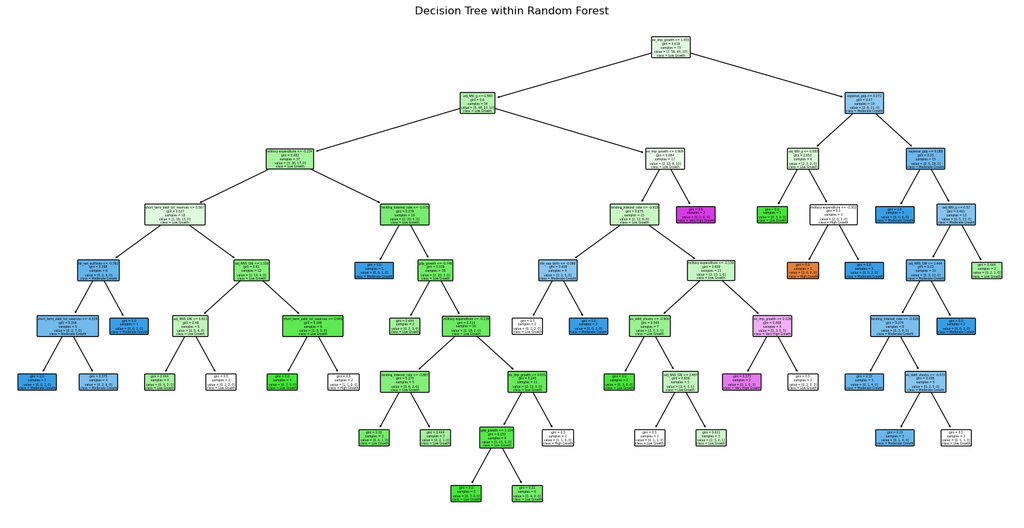

```python
plt.figure(figsize=(20, 10))
plot_tree(baseline_rf_model.estimators_[0], filled=True, feature_names=X.columns, class_names=np.unique(Y), rounded=True)
plt.title("Decision Tree within Random Forest")
plt.show()
```

This is the basal tree for random forest.

## Random Forest Classifer - GridSearchCV

```python
param_grid = {
    'n_estimators': [50, 100, 150],
    'max_depth': [5, 10, 20],
    'min_samples_split': [2, 5, 10],
    'min_samples_leaf': [1, 2, 4]
}
```

```python
grid_search = GridSearchCV(baseline_rf_model, param_grid, cv=5, scoring='accuracy')
grid_search.fit(X_train, y_train)
```

```
GridSearchCV(cv=5, estimator=RandomForestClassifier(random_state=42),
             param_grid={'max_depth': [5, 10, 20],
                         'min_samples_leaf': [1, 2, 4],
                         'min_samples_split': [2, 5, 10],
                         'n_estimators': [50, 100, 150]},
             scoring='accuracy')
```

```python
best_rf_model = grid_search.best_estimator_
best_rf_model
```

```
RandomForestClassifier(max_depth=5, min_samples_leaf=2, min_samples_split=10,
                       n_estimators=50, random_state=42)
```

```python
rf_model= RandomForestClassifier(max_depth=5, min_samples_leaf=2, min_samples_split=10, n_estimators=50, random_state=42)
```

```python
train_predictions1 = best_rf_model.predict(X_train)
test_predictions1 = best_rf_model.predict(X_test)
val_predictions1 = best_rf_model.predict(X_val)
```

```python
# Calculate accuracy for training, test, and validation sets
train_accuracy1 = accuracy_score(y_train, train_predictions)
test_accuracy1 = accuracy_score(y_test, test_predictions)
val_accuracy1 = accuracy_score(y_val, val_predictions)

# Display accuracy for training, test, and validation sets
print("\nAccuracy - Training Set for GridSearchCV Random Forest:", train_accuracy1)
print("Accuracy - Test Set for GridSearchCV Random Forest:", test_accuracy1)
print("Accuracy - Validation Set for GridSearchCV Random Forest:", val_accuracy1)
```

[output not shown]

```python
# Print classification report for the model on the training set
print("Classification Report for Random Forest with GridSearchCV on Training Set:")
print(classification_report(y_train, train_predictions1))

# Print classification report for the model on the test set
print("Classification Report for Random Forest on Test Set:")
print(classification_report(y_test, test_predictions1))

# Print classification report for the model on the validation set
print("Classification Report for Random Forest on Validation Set:")
print(classification_report(y_val, val_predictions1))
```

```
Classification Report for Random Forest with GridSearchCV on Training Set:
                  precision    recall  f1-score   support

     High Growth       0.00      0.00      0.00         9
      Low Growth       0.63      0.57      0.60        51
 Moderate Growth       0.61      0.88      0.72        49
Very High Growth       0.00      0.00      0.00         8

        accuracy                           0.62       117
       macro avg       0.31      0.36      0.33       117
    weighted avg       0.53      0.62      0.56       117

Classification Report for Random Forest on Test Set:
                  precision    recall  f1-score   support

     High Growth       0.00      0.00      0.00         4
      Low Growth       0.43      0.32      0.36        19
 Moderate Growth       0.32      0.67      0.43        12
Very High Growth       0.00      0.00      0.00         4

        accuracy                           0.36        39
       macro avg       0.19      0.25      0.20        39
    weighted avg       0.31      0.36      0.31        39

Classification Report for Random Forest on Validation Set:
                  precision    recall  f1-score   support

     High Growth       0.00      0.00      0.00         4
      Low Growth       0.62      0.44      0.52        18
 Moderate Growth       0.27      0.64      0.38        11
Very High Growth       0.00      0.00      0.00         6

        accuracy                           0.38        39
       macro avg       0.22      0.27      0.22        39
    weighted avg       0.36      0.38      0.34        39
```

In terms of the classification report, the performance of the Random Forest classifier with GridSearchCV tuning is mediocre on training, test, and validation datasets. The model exhibits a moderate ability to learn from the training data, with a training set accuracy of 62%. However, as evidenced by the consistent 36-38% accuracy on the test and validation sets, its generalisation to new data is limited. There are difficulties in correctly classifying instances, especially for the “High Growth” and “Very High Growth” classes, as indicated by the precision, recall, and F1-score metrics.

[figure not shown]

[figure not shown]

[figure not shown]

```python
plot_confusion_matrix(y_train, train_predictions1, classes=np.unique(Y), title="Confusion Matrix - RandomisedSearchCV - Training Set")
plot_confusion_matrix(y_test, test_predictions1, classes=np.unique(Y), title="Confusion Matrix - RandomisedSearchCV - Test Set")
plot_confusion_matrix(y_val, val_predictions1, classes=np.unique(Y), title="Confusion Matrix - RandomisedSearchCV -Validation Set")
```

We can see the same thing here, with training set misclassifying the most.

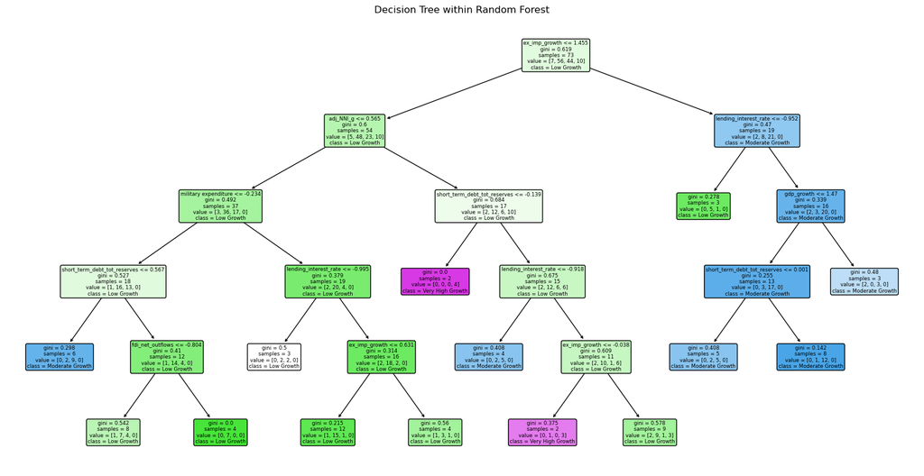

```python
plt.figure(figsize=(20, 10))
plot_tree(best_rf_model.estimators_[0], filled=True, feature_names=X.columns, class_names=np.unique(Y), rounded=True)
plt.title("Decision Tree within Random Forest")
plt.show()
```

The final pruned tree.

## Discussion

# Conclusion

This module has taught me the important of looking into the kind of data and better optimal parameter tuning techniques. We see that all the models shown have their own flaws, and hence, I’d like to educate myself more on this with the upcoming classes.

# Sources

1. sklearn.metrics.ConfusionMatrixDisplay Documentation. (n.d.). Retrieved from https://scikit-learn.org/stable/modules/generated/sklearn.metrics.ConfusionMatrixDisplay.html
2. scikit-learn Decision Tree Module Documentation. (n.d.). Retrieved from https://scikit-learn.org/stable/modules/tree.html
3. scikit-learn DecisionTreeClassifier Documentation. (n.d.). Retrieved from https://scikit-learn.org/stable/modules/generated/sklearn.tree.DecisionTreeClassifier.html
4. Decision Tree Classifier Explained in Real Life: Picking a Vacation Destination. (n.d.). Retrieved from https://towardsdatascience.com/decision-tree-classifier-explained-in-real-life-picking-a-vacation-destination-6226b2b60575
5. Hyperparameter Tuning of Decision Tree Classifier using GridSearchCV. (n.d.). Retrieved from https://plainenglish.io/blog/hyperparameter-tuning-of-decision-tree-classifier-using-gridsearchcv-2a6ebcaffeda
6. Decision Tree Classifier: Working on Moons Dataset using GridSearchCV to Find Best Hyperparameters. (n.d.). Retrieved from https://medium.com/analytics-vidhya/decisiontree-classifier-working-on-moons-dataset-using-gridsearchcv-to-find-best-hyperparameters-ede24a06b489
7. Hyperparameter Tuning using Randomized Search. (n.d.). Retrieved from https://www.analyticsvidhya.com/blog/2022/11/hyperparameter-tuning-using-randomized-search/
8. Random Forest - IBM Topics. (n.d.). Retrieved from https://www.ibm.com/topics/random-forest#:~:text=Random%20forest%20is%20a%20commonly,both%20classification%20and%20regression%20problems.
9. sklearn.ensemble.RandomForestClassifier Documentation. (n.d.). Retrieved from https://scikit-learn.org/stable/modules/generated/sklearn.ensemble.RandomForestClassifier.html
10. Hyperparameter Tuning the Random Forest in Python using scikit-learn. (n.d.). Retrieved from https://towardsdatascience.com/hyperparameter-tuning-the-random-forest-in-python-using-scikit-learn-28d2aa77dd74